# Practical 7

Vahe Avagyan Mathematical & Statistical Methods group – Biometris Wageningen University & Research **Linear and Generalized Linear Models** vahe.avagyan@wur.nl

### Packages

First, you need install and load the required R packages.

```r
## Set working directory to convenience
setwd(" ")

## Packages (install and invoke)
pkgs <- rownames(installed.packages())
if(!"EnvStats" %in% pkgs) install.packages("EnvStats")
if(!"MASS" %in% pkgs) install.packages("MASS")
if(!"car" %in% pkgs) install.packages("car")
if(!"faraway" %in% pkgs) install.packages("faraway")
if(!"splines" %in% pkgs) install.packages("splines")
```

The code recognizes if certain packages are missing from your package library and, if so, will install them automatically.

Now, we need to load the packages:

```r
library(EnvStats)
library(car)
library(faraway)
library(splines)
library(MASS)
```

## Exercise 1.

The task is to examine the assumptions for constant variance and normality. For each case, provide the following

1. The QQ plot and its interpretation
2. Plot the residuals vs fitted values and interpret it.

** Answer **

Let’s start with $n=20$.

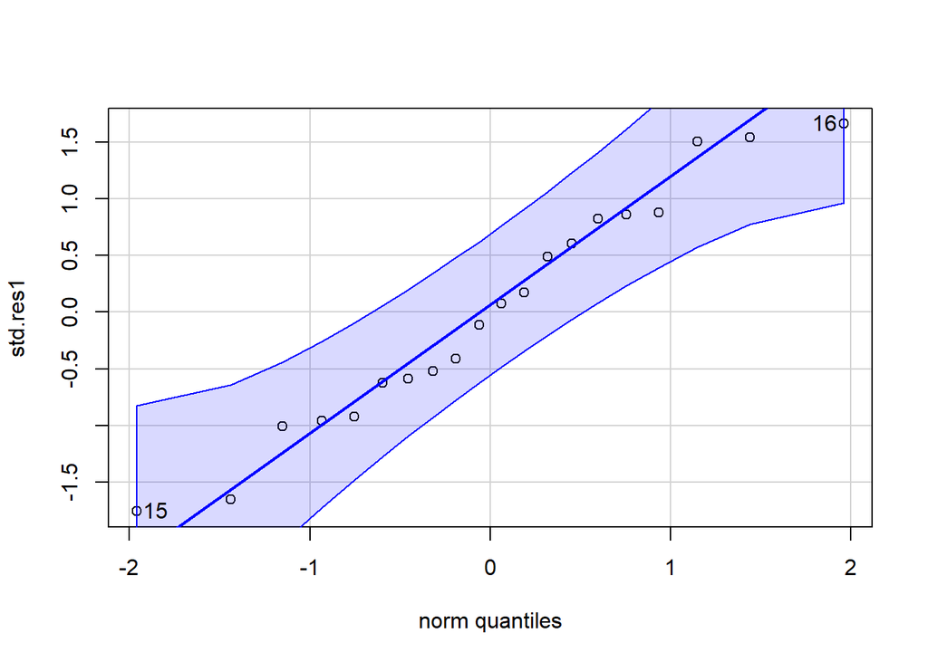

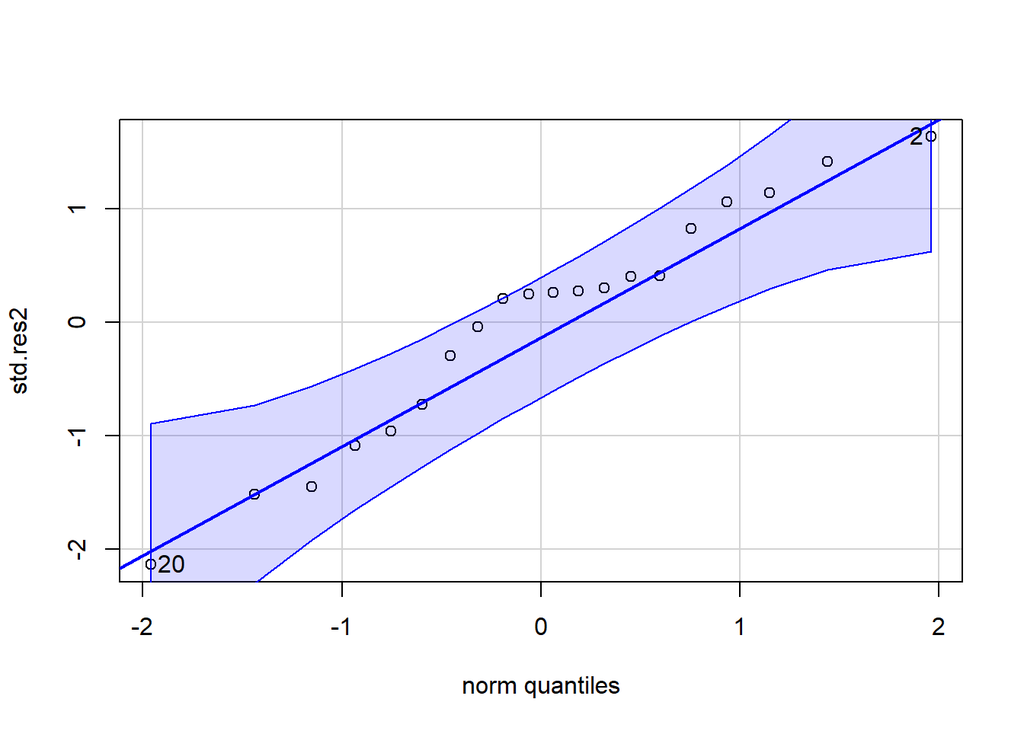

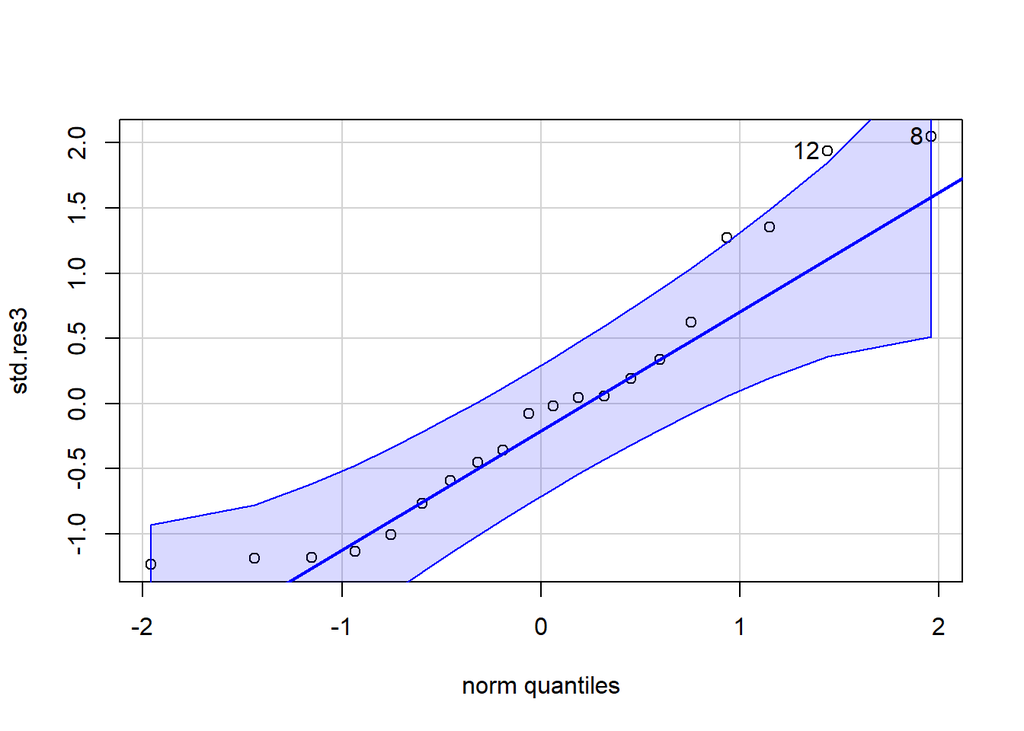

```r
 set.seed(12345)
 n <- 20
 x <- runif(n)
 eps1 <- rnorm(n)
 eps2 <- rnorm(n, sd=sqrt(2*x))
 eps3 <- rchisq(n,2)-2
 y1 <- 5 + 8*x + eps1
 y2 <- 5 + 8*x + eps2
 y3 <- 5 + 8*x + eps3
 lmo1 <- lm(y1 ~ x); std.res1 <- rstandard(lmo1)
 lmo2 <- lm(y2 ~ x); std.res2 <- rstandard(lmo2)
 lmo3 <- lm(y3 ~ x); std.res3 <- rstandard(lmo3)
 q1<-car::qqPlot(std.res1); q2<-car::qqPlot(std.res2); q3<-car::qqPlot(std.res3);
```

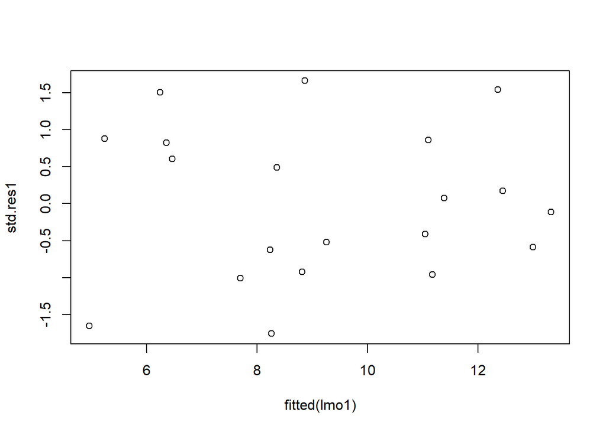

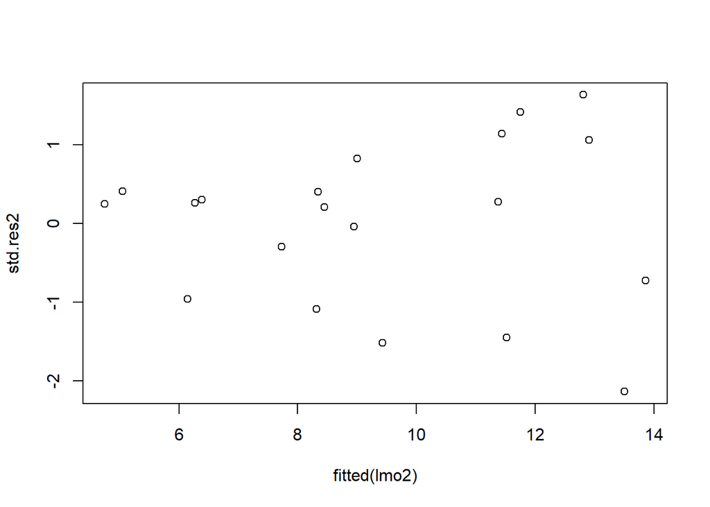

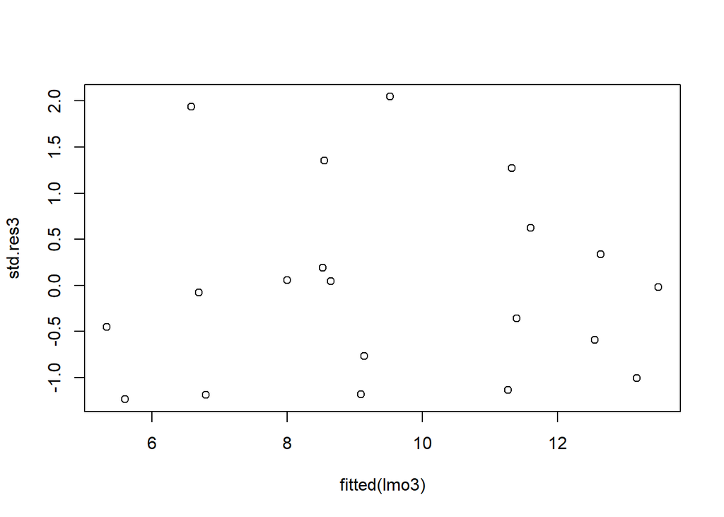

```r
 plot(std.res1 ~ fitted(lmo1)); plot(std.res2 ~ fitted(lmo2)); plot(std.res3 ~ fitted(lmo3))
```

Sample size seems to be too small to see clear trends. In QQ-plot of model 3 results one observation is outside the confidence envelope, which may be expected for residuals skewed to the right. A slight loudspeaker shape is visible in the plot of standardized residuals versus fitted values for model 2 results.

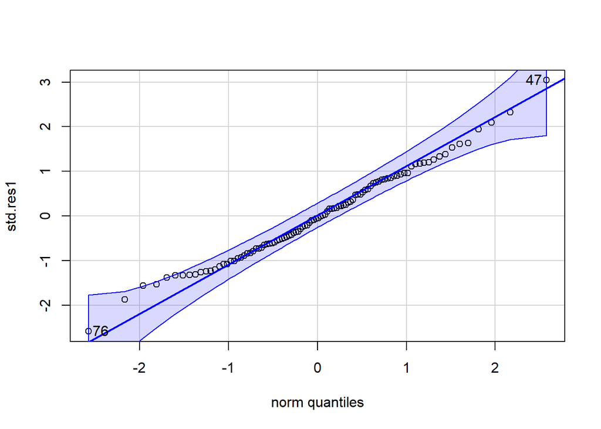

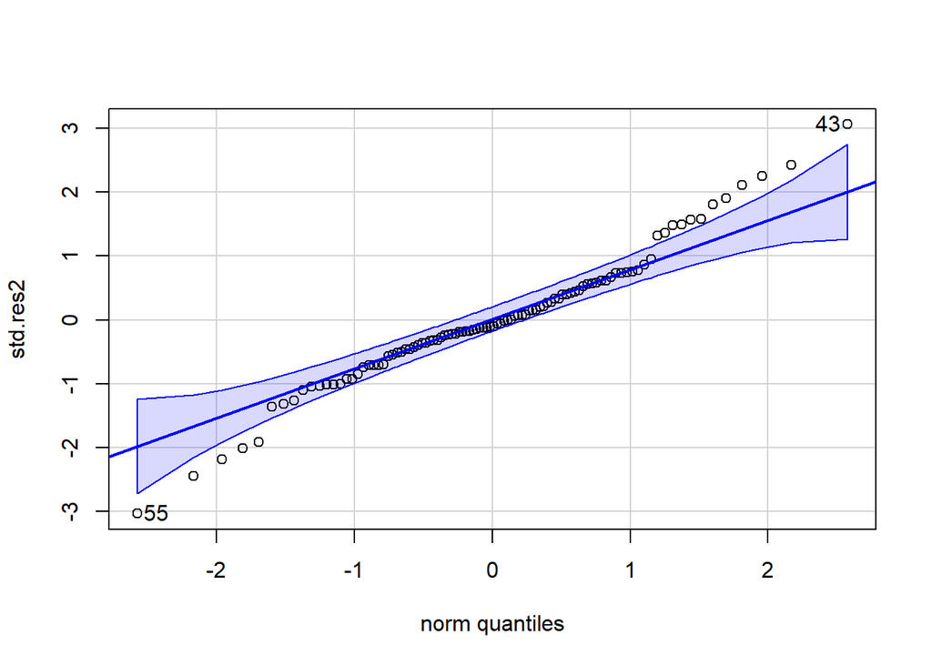

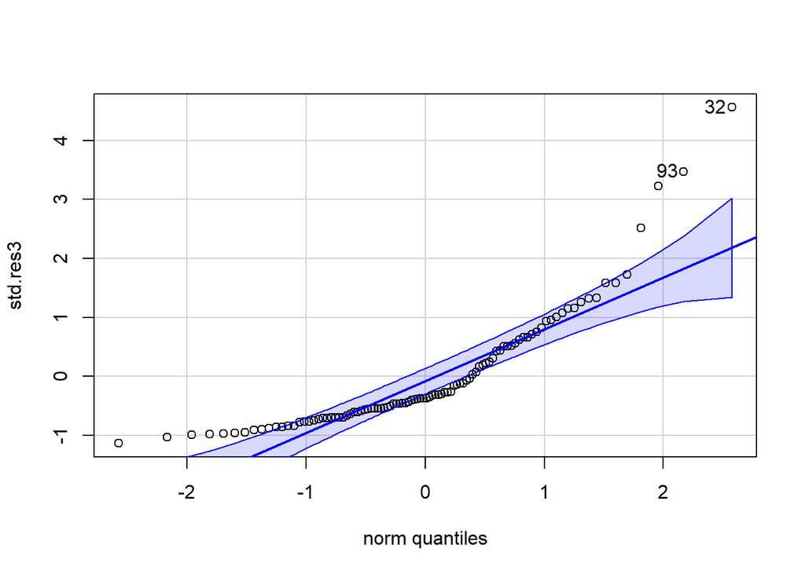

```r
set.seed(6789)
 n <- 100
 x <- runif(n)
 eps1 <- rnorm(n)
 eps2 <- rnorm(n, sd=sqrt(2*x))
 eps3 <- rchisq(n,2)-2
 y1 <- 5 + 8*x + eps1
 y2 <- 5 + 8*x + eps2
 y3 <- 5 + 8*x + eps3
 lmo1 <- lm(y1 ~ x); std.res1 <- rstandard(lmo1)
 lmo2 <- lm(y2 ~ x); std.res2 <- rstandard(lmo2)
 lmo3 <- lm(y3 ~ x); std.res3 <- rstandard(lmo3)
 q1<-car::qqPlot(std.res1); q2<-car::qqPlot(std.res2); q3<-car::qqPlot(std.res3);
```

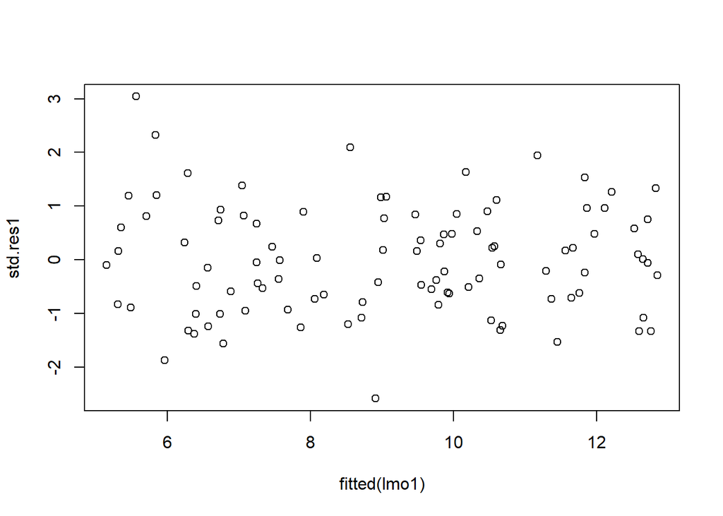

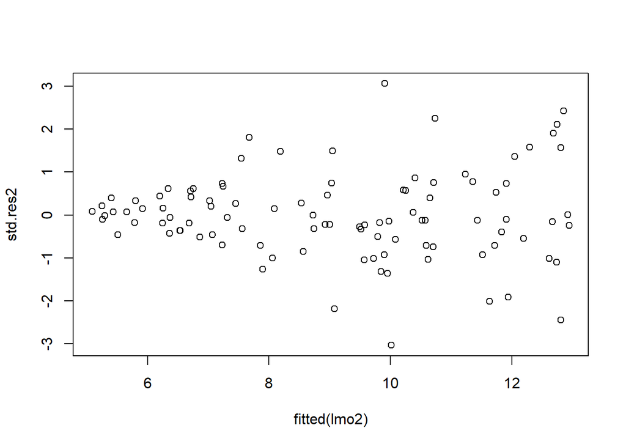

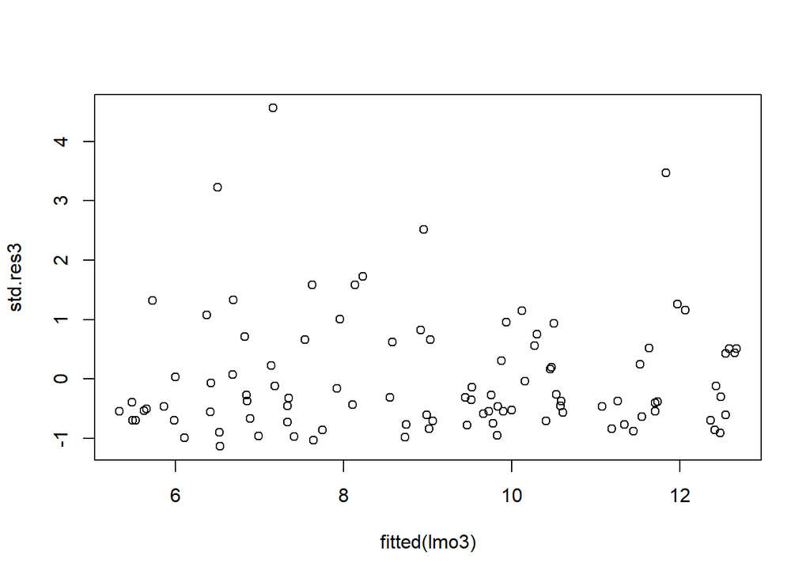

```r
 plot(std.res1 ~ fitted(lmo1)); plot(std.res2 ~ fitted(lmo2)); plot(std.res3 ~ fitted(lmo3))
```

Patterns are much more clear now. Model 1 results looks ok. Model 2 results shows evident “loudspeaker shape” in plot of residuals versus fitted values. Many observations outside the confidence envelope in QQ-plot. Model 3 results shows distinctive skewness to the right in normal QQ-plot; asymmetry of distribution can also be seen in plot of residuals versus fitted values; many observations are outside the confidence envelope in QQ-plot. The largest standardized residual is even larger than 4.

## Exercise 2.

Experimenting with component-plus-residual plots:

Generate random samples of 100 observations according to each of the schemes below. In each case, construct the component-plus-residual plots for $X_1$ and $X_2$. Do these plots accurately capture the partial relationships between $Y$ and each of $X_1$ and $X_2$? Whenever they appear, $\epsilon$ and $\delta$ are N(0; 1) and independent of each other and of the other variables. You can use the command `crPlot()` from the `car` package.

Choose any three cases to do in the classroom. Try the others at home.

1. Independent $X's$ and a linear regression: $X_1$ and $X_2$ independent and uniformly distributed on the interval [0; 1], and $Y = X_1 + X_2 + 0.1\epsilon$.
2. Linearly related $Xs$ and a linear regression: $X_1$ uniformly distributed on the interval [0; 1], $X_2 = X_1 + 0.1\delta$ and $Y = X_1 + X_2 + 0.1\epsilon$.
3. Independent $Xs$ and a nonlinear regression on one $X$: $X_1$ and $X_2$ independent and uniformly distributed on interval [0; 1]; $Y = 2(X_1 - 0.5)^2 + X_2 + 0.1\epsilon$.
4. Linearly related $Xs$ and a nonlinear regression on one $X$: $X_1$ uniformly distributed on the interval [0; 1], $X_2 = X_1 + 0.1\delta$; $Y = 2(X_1 - 0.5)^2 + X_2 + 0.1\epsilon$.
5. Nonlinearly related $X's$ and a linear regression: $X_1$ uniformly distributed on the interval [0; 1]; $X_2 = |X_1 - 0.5|$; $Y = X_1 + X_2 + 0.02\epsilon$.
6. Nonlinearly related $X's$ and a linear regression on one $X$: $X_1$ uniformly distributed on the interval [0; 1]; $X_2 = |X1 - 0.5|$; $Y = 2(X_1 - 0.5)^2 + X_2 + 0.02\epsilon$.

**Answer**

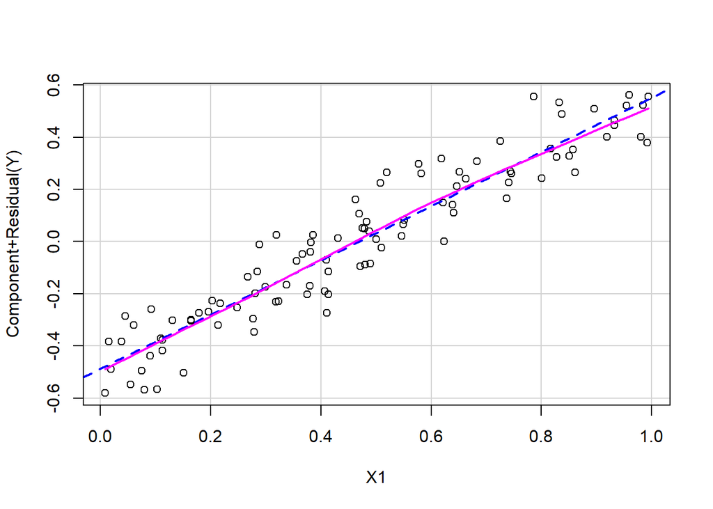

```r
 X1 <- runif(100)
 X2 <- runif(100)
 epsilon <- rnorm(100)
 Y <- X1 + X2 + 0.1*epsilon
 lmo.a <- lm(Y ~ X1 + X2)
 crPlot(lmo.a,X1) # function from car library
```

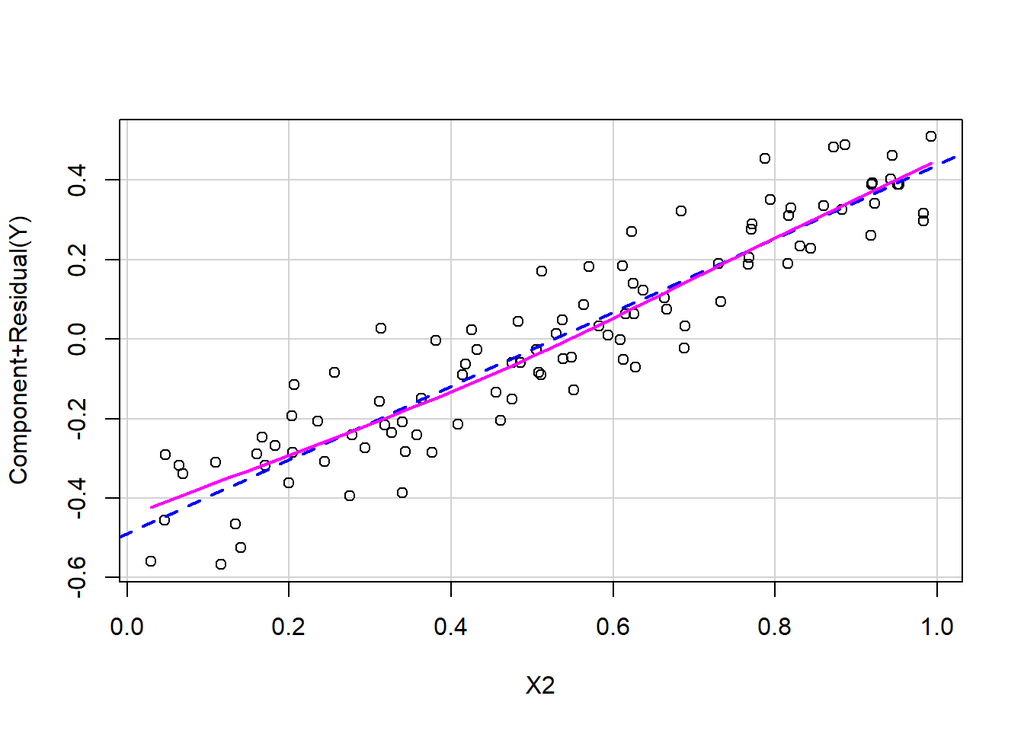

```r
 crPlot(lmo.a,X2)
```

Plots look OK. No indication of deviation from linearity, as expected.

You can also do the same manually, without any fancy smoothers.

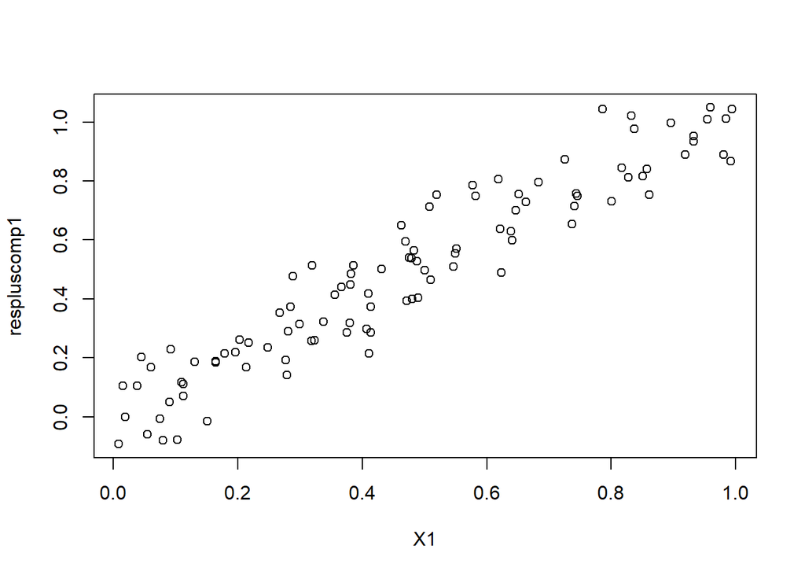

```r
res <- residuals(lmo.a)
respluscomp1 <- residuals(lmo.a) + coef(lmo.a)[2]*X1
respluscomp2 <- residuals(lmo.a) + coef(lmo.a)[3]*X2
plot(respluscomp1 ~ X1)
```

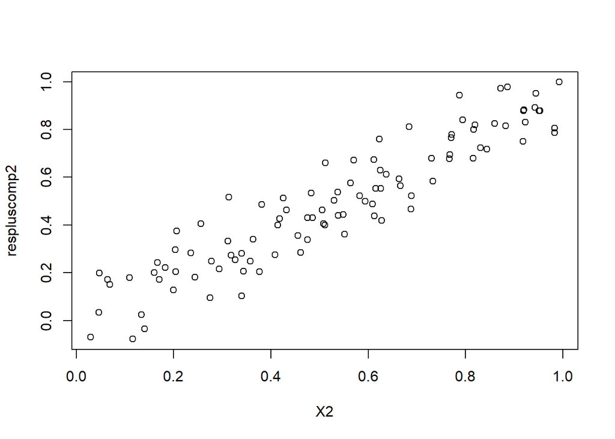

```r
plot(respluscomp2 ~ X2)
```

Notice that `crplot()` gives y-axis centered around 0, so it uses centered regressors to construct “residual-plus-component”, whereas we use below the original not-centered regressor.

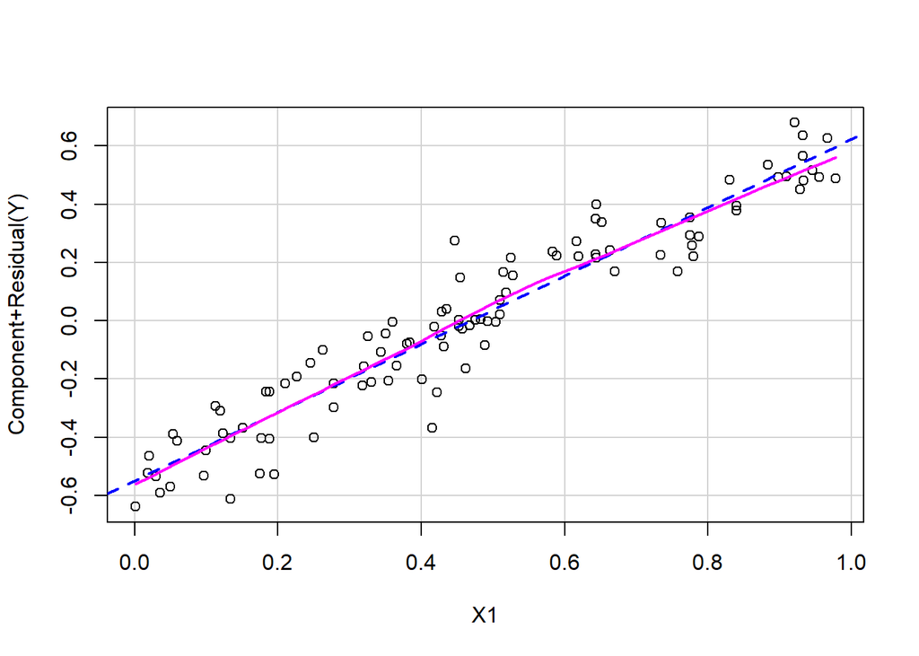

```r
 X1 <- runif(100)
 delta <- rnorm(100)
 epsilon <- rnorm(100)
 X2 <- X1 + 0.1*delta
 Y <- X1 + X2 + 0.1*epsilon
 lmo.b <- lm(Y ~ X1 + X2)
 crPlot(lmo.b,X1)
```

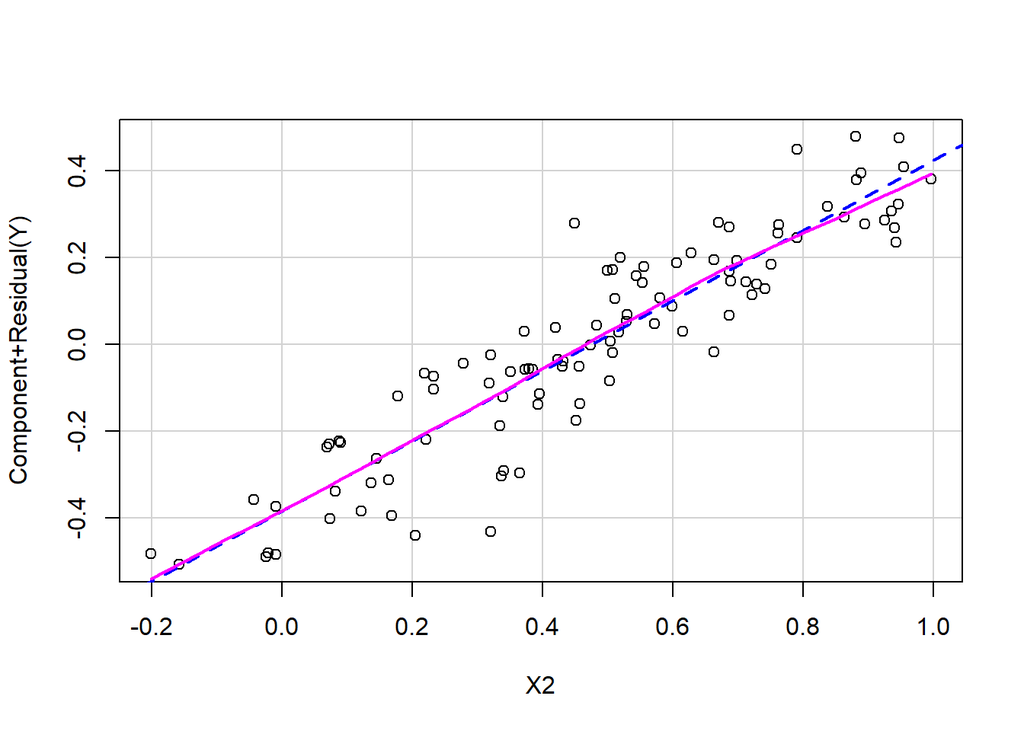

```r
 crPlot(lmo.b,X2)
```

Plots look largely same as in case of independent regressors. Standard error of coefficients is larger now, but this is not visible in plot.

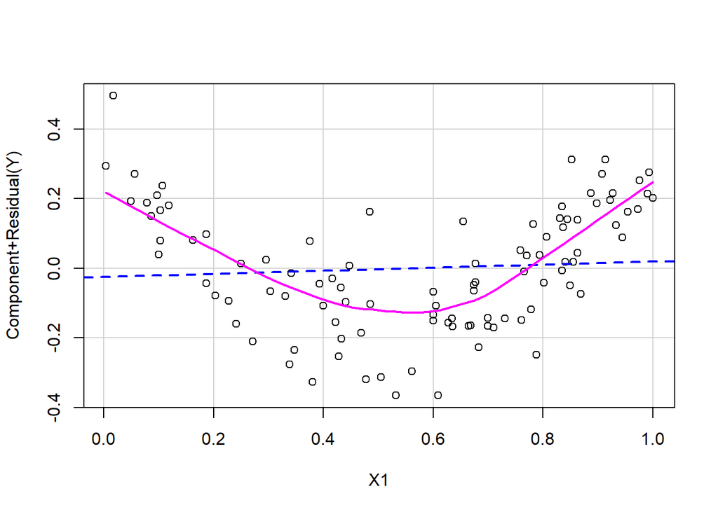

```r
 X1 <- runif(100)
 X2 <- runif(100)
 epsilon <- rnorm(100)
 Y <- 2*(X1-0.5)^2 + X2 + 0.1*epsilon
 lmo.c <- lm(Y ~ X1 + X2)
 crPlot(lmo.c,X1)
```

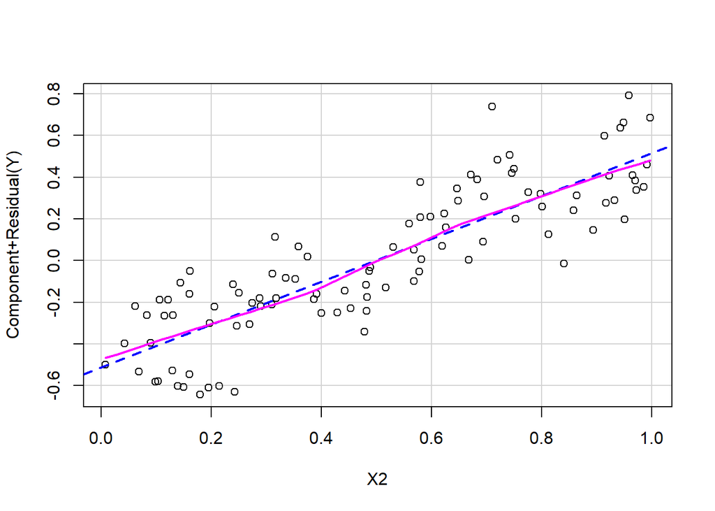

```r
 crPlot(lmo.c,X2)
```

Nonlinearity in plot versus $X_1$ is obvious.

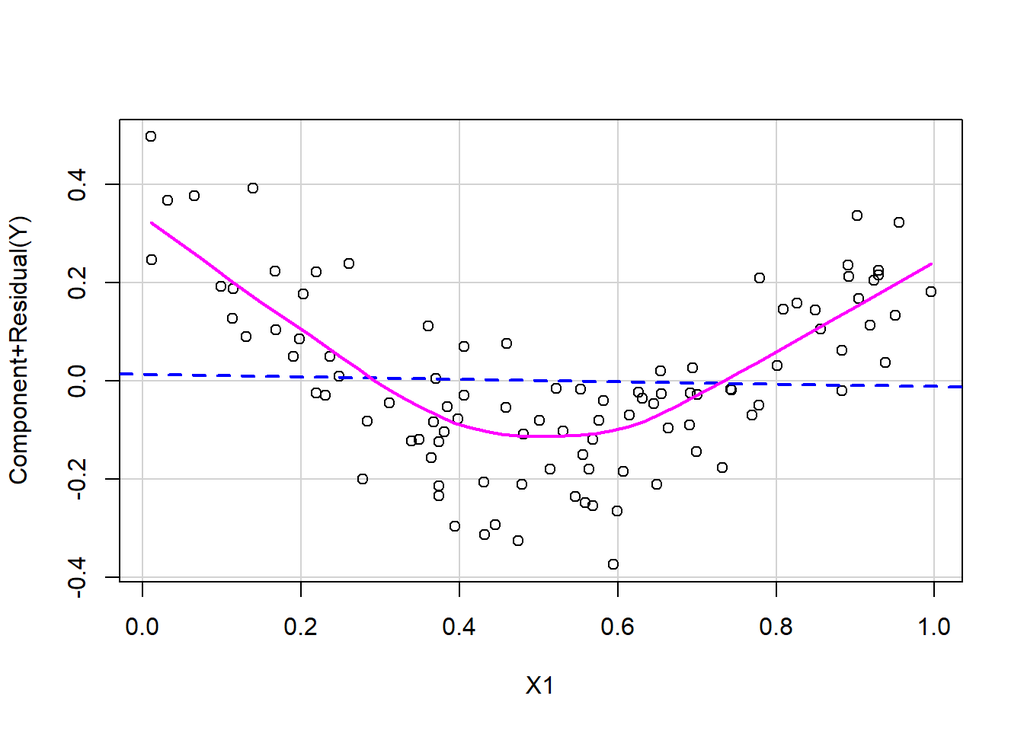

```r
 X1 <- runif(100)
 delta <- rnorm(100)
 X2 <- X1 + 0.1*delta
 epsilon <- rnorm(100)
 Y <- 2*(X1-0.5)^2 + X2 + 0.1*epsilon
 lmo.d <- lm(Y ~ X1 + X2)
 crPlot(lmo.d,X1)
```

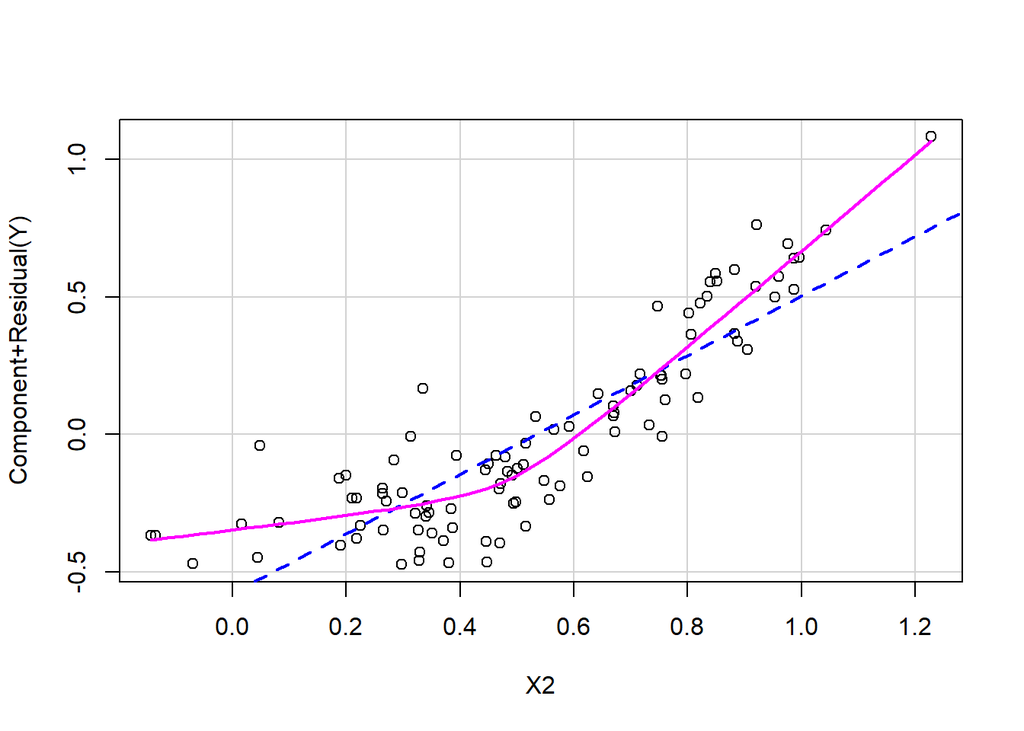

```r
 crPlot(lmo.d,X2)
```

Again, nonlinearity in plot versus $X_1$ is obvious. The “leakage” from $X_1$ to $X_2$ indeed is visible: there appears to be non-linearity in the relationship of $Y$ with $X_2$ as well.

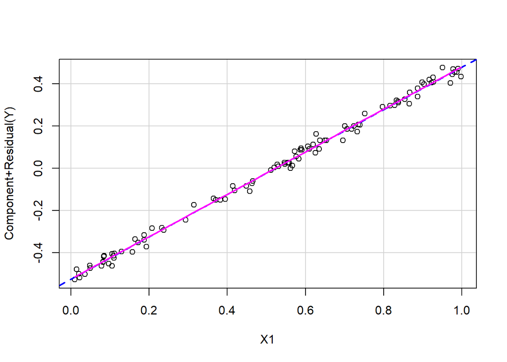

```r
 X1 <- runif(100)
 X2 <- abs(X1 - 0.5)
 epsilon <- rnorm(100)
 Y <- X1 + X2 + 0.02*epsilon
 lmo.e <- lm(Y ~ X1 + X2)
 crPlot(lmo.e,X1)
```

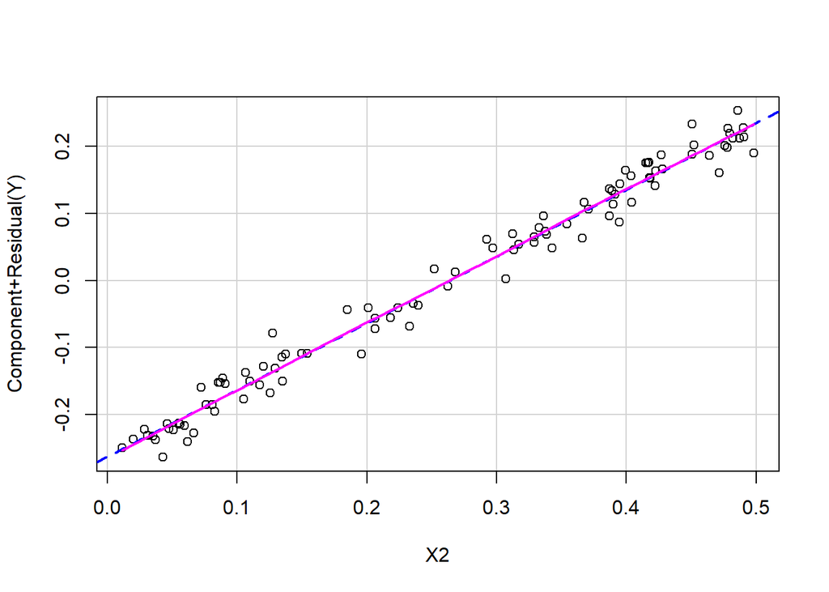

```r
 crPlot(lmo.e,X2)
```

Plots look OK.

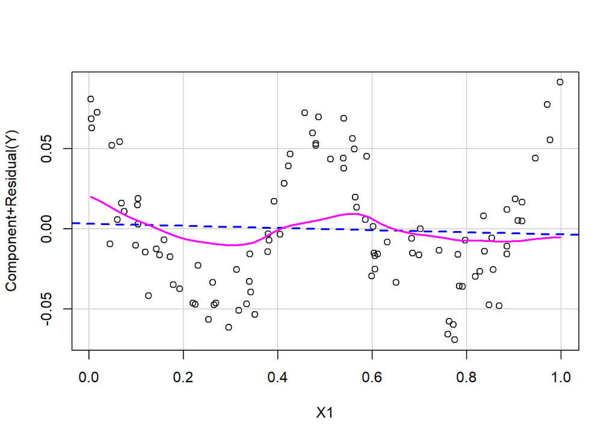

```r
 X1 <- runif(100)
 X2 <- abs(X1 - 0.5)
 epsilon <- rnorm(100)
 Y <- 2*(X1-0.5)^2 + X2 + 0.02*epsilon
 lmo.f <- lm(Y ~ X1 + X2)
 crPlot(lmo.f,X1)
```

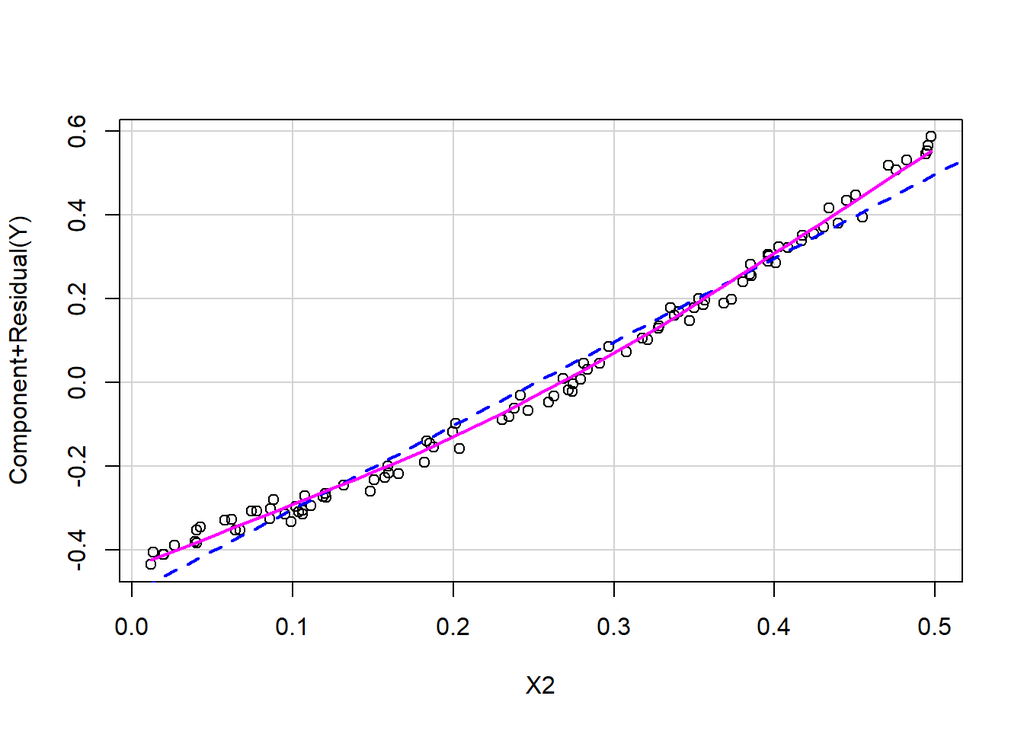

```r
 crPlot(lmo.f,X2)
```

Nonlinearity in partial relationship of $Y$ with $X_1$ is visible.

## Exercise 3

Recall the Savings data that we have seen during the lecture. Perform Box-Cox transformation on the datausing `boxcox()` command from `MASS` package.

1. Plot the log-likelihood vs lambda. Indicate the confidence interval provided by the plot (you need to narrow the range of lambda to make it visible, see the code).
2. Give the estimated lambda (i.e., the one that maximizes the log-likelihood).
3. Which test do you need to consider to check if the response of the `savings`needs a transformation?
4. Look at your confidence interval. Do you reject or fail to reject the test in c)?

** Answer **

```r
data(savings)
head(savings)
```

```
##              sr pop15 pop75     dpi ddpi
## Australia 11.43 29.35  2.87 2329.68 2.87
## Austria   12.07 23.32  4.41 1507.99 3.93
## Belgium   13.17 23.80  4.43 2108.47 3.82
## Bolivia    5.75 41.89  1.67  189.13 0.22
## Brazil    12.88 42.19  0.83  728.47 4.56
## Canada     8.79 31.72  2.85 2982.88 2.43
```

```r
g <- lm(sr ~ pop15+pop75+dpi+ddpi,savings)
summary(g)
```

```
##
## Call:
## lm(formula = sr ~ pop15 + pop75 + dpi + ddpi, data = savings)
##
## Residuals:
##     Min      1Q  Median      3Q     Max
## -8.2422 -2.6857 -0.2488  2.4280  9.7509
##
## Coefficients:
##               Estimate Std. Error t value Pr(>|t|)
## (Intercept) 28.5660865  7.3545161   3.884 0.000334 ***
## pop15       -0.4611931  0.1446422  -3.189 0.002603 **
## pop75       -1.6914977  1.0835989  -1.561 0.125530
## dpi         -0.0003369  0.0009311  -0.362 0.719173
## ddpi         0.4096949  0.1961971   2.088 0.042471 *
## ---
## Signif. codes:  0 '***' 0.001 '**' 0.01 '*' 0.05 '.' 0.1 ' ' 1
##
## Residual standard error: 3.803 on 45 degrees of freedom
## Multiple R-squared:  0.3385, Adjusted R-squared:  0.2797
## F-statistic: 5.756 on 4 and 45 DF,  p-value: 0.0007904
```

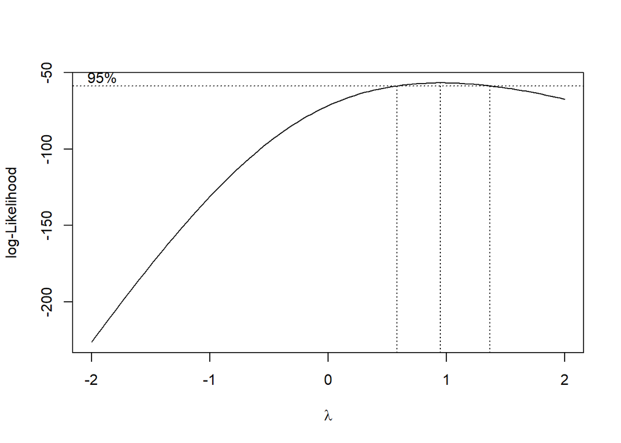

```r
bc <- boxcox(g,plotit=T)
```

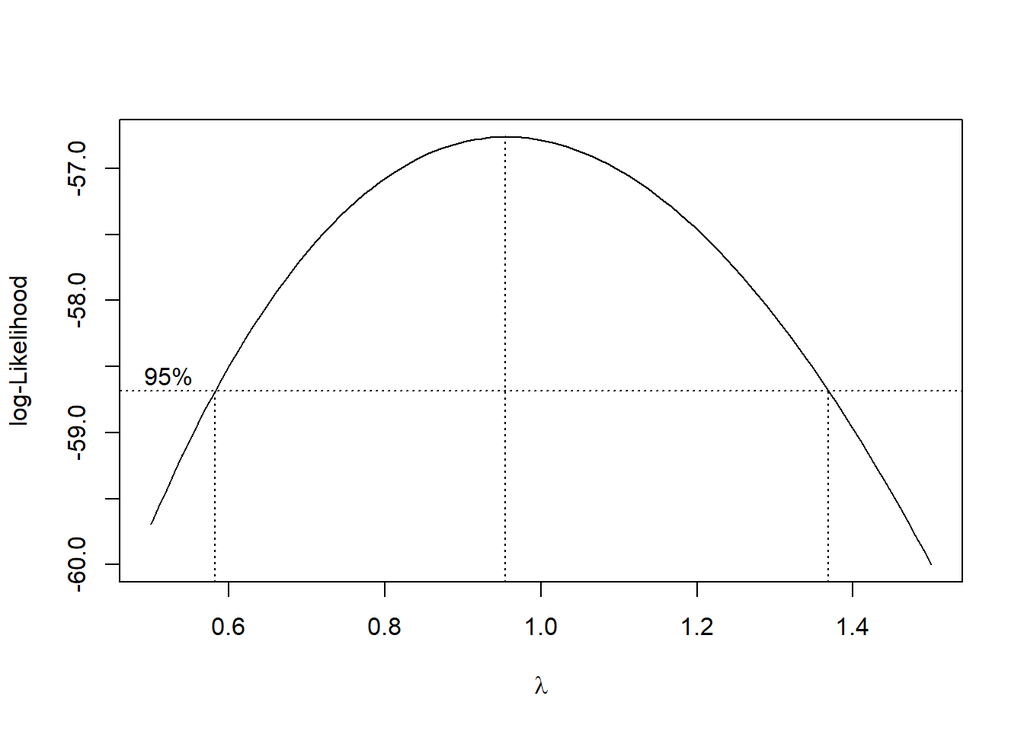

```r
#We can narrow the range of lambda, to make it more visible
bc <- boxcox(g,plotit=T,lambda=seq(0.5,1.5,by=0.1))
```

```r
# Exact lambda
lambda <- bc$x[which.max(bc$y)]
lambda
```

```
## [1] 0.9545455
```

The first plot is too broad. We can narrow the range of $\lambda$ in the second plot so that we can read off the confidence interval more easily. The estimate of $\lambda$ is 0.954. The confidence interval for $\lambda$ runs from about 0.6 to about 1.4. To check if we need a transformation, we need to conduct the following test: $H_0: \lambda=1$ vs $H_0: \lambda\not = 1$. We can see that there is no good reason to transform, because the confidence interval includes 1.

## Exercise 4

Let’s look at an example concerning the number of species of tortoise on the various Galapagos Islands. There are 30 cases (Islands) and 7 variables in the dataset `gala`. The variables are

- Species: The number of species of tortoise found on the island
- Endemics: The number of endemic species
- Elevation: The highest elevation of the island
- Nearest: The distance from the nearest island (km)
- Scruz: The distance from Santa Cruz island (km)
- Adjacent: The area of the adjacent island (km2)
1. Regress Species against all the other variables. Provide the summary of the model. What is the $R^2$ of the model.
2. Provide the QQ-plot of the response variable. What is your opinion?
3. Perform Box-Cox transformation and provide the results. Does the response in the `gala` data need transformation?
4. Perform the Box-Cox transoformation on the response variable. Provide the QQ-plot of the response variable again after the transformation. Discuss the results.

** Answer **

```r
data(gala)
 g <- lm(Species ~ Area + Elevation + Nearest + Scruz + Adjacent,gala)
 summary(g)
```

```
##
## Call:
## lm(formula = Species ~ Area + Elevation + Nearest + Scruz + Adjacent,
##     data = gala)
##
## Residuals:
##      Min       1Q   Median       3Q      Max
## -111.679  -34.898   -7.862   33.460  182.584
##
## Coefficients:
##              Estimate Std. Error t value Pr(>|t|)
## (Intercept)  7.068221  19.154198   0.369 0.715351
## Area        -0.023938   0.022422  -1.068 0.296318
## Elevation    0.319465   0.053663   5.953 3.82e-06 ***
## Nearest      0.009144   1.054136   0.009 0.993151
## Scruz       -0.240524   0.215402  -1.117 0.275208
## Adjacent    -0.074805   0.017700  -4.226 0.000297 ***
## ---
## Signif. codes:  0 '***' 0.001 '**' 0.01 '*' 0.05 '.' 0.1 ' ' 1
##
## Residual standard error: 60.98 on 24 degrees of freedom
## Multiple R-squared:  0.7658, Adjusted R-squared:  0.7171
## F-statistic:  15.7 on 5 and 24 DF,  p-value: 6.838e-07
```

```r
 summary(g)$r.squared
```

```
## [1] 0.7658469
```

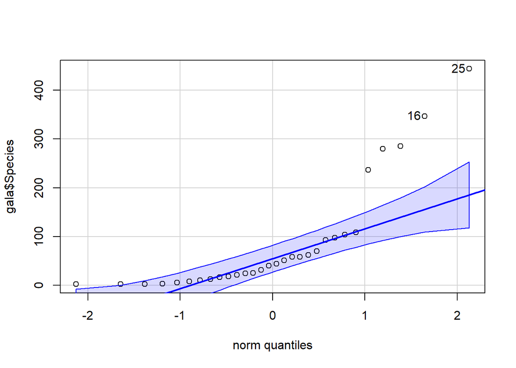

```
## [1] 25 16
```

```r
car::qqPlot(gala$Species)
```

```r
#car::qqPlot(bc_Species)
```

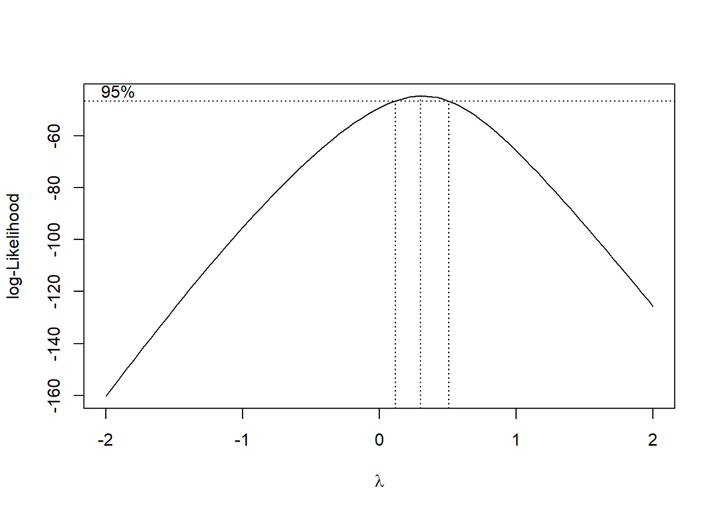

```r
 bc <- boxcox(g,plotit=T)
```

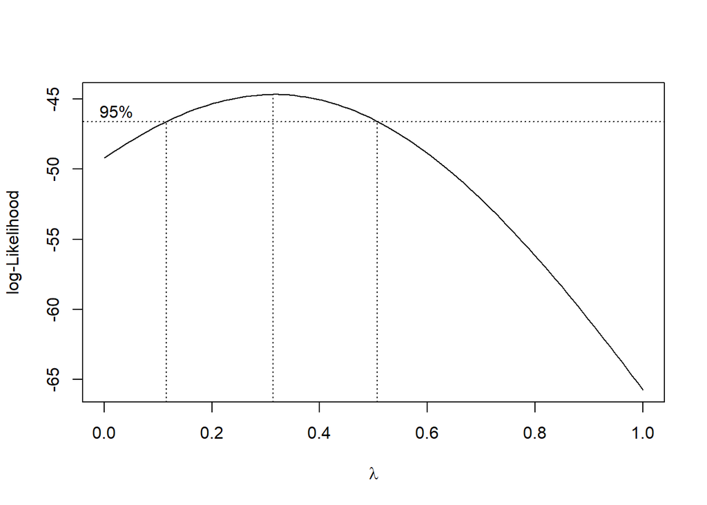

```r
 bc <- boxcox(g,lambda=seq(0.0,1.0,by=0.05),plotit=T)
```

```r
lambda <- bc$x[which.max(bc$y)]
lambda
```

```
## [1] 0.3131313
```

```r
bc_Species <- (gala$Species^lambda - 1) / lambda
#car::qqPlot(bc_Species)
```

3. We see that perhaps a cube-root transformation might be best here. A square root is also a possibility as this falls just within the confidence intervals. Certainly there is a strong need to transform.

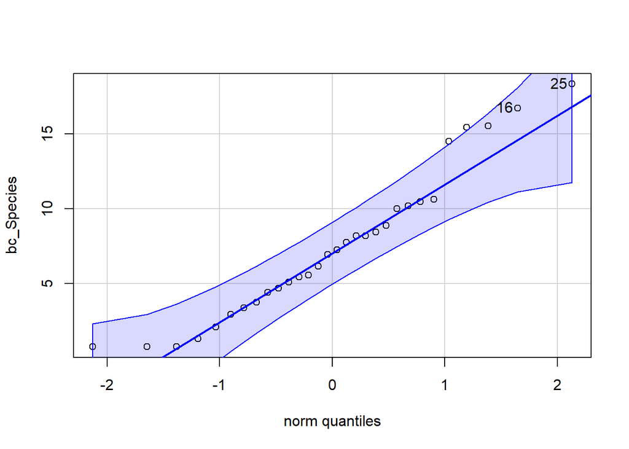

```
## [1] 25 16
```

```r
car::qqPlot(bc_Species)
```

4. The QQ-plot of the transformed response shows less deviation from Normality compared to that for the non-transformed response variable.